# Visualizing Data with Graphs

Paul D. Kieffaber, Ph.D.

Spring 2026

## Why Do We Need to Visualize Data?

> “Graphs are not just decorative. They are tools for reasoning about data.”
- **The Goal**: Represent data clearly, revealing distributions, differences, outliers, and trends.
- The Challenge: Moving from raw numbers to interpretation.
- Before graphing, ask:  
  What kind of variables am I trying to represent?  
  What pattern do I want the reader to see?

## Choosing the Right Graph

Match your graph to your **data type** and **research question**:

- **Categorical Variables:**
  - **Pie Chart:** Parts of a whole (use sparingly).
  - **Column Chart:** Comparing counts, proportions, or descriptive statistics across categories.
- **Continuous Variables:**
  - **Histogram:** Distribution of one numeric variable.
  - **Boxplot:** Comparing distributions across groups.
  - **Line Chart:** Trends across ordered values (especially time).
  - **Scatterplot:** Relationships between two continuous variables.

## Histograms

**When to Use:** - Examining the distribution of one continuous variable. - Checking for symmetry, skew, multimodality, or gaps.

**When NOT to Use:** - Categorical variables. - Comparing a large number of groups.

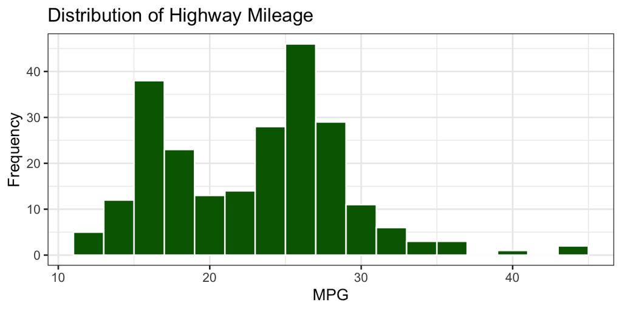

## Pie Charts

**When to Use:** - Categorical variables. - Small number of categories. - Goal is to emphasize relative proportions (parts of a whole).

**When NOT to Use:** - Many categories (becomes unreadable). - Categories have very similar proportions (angles are hard to compare).

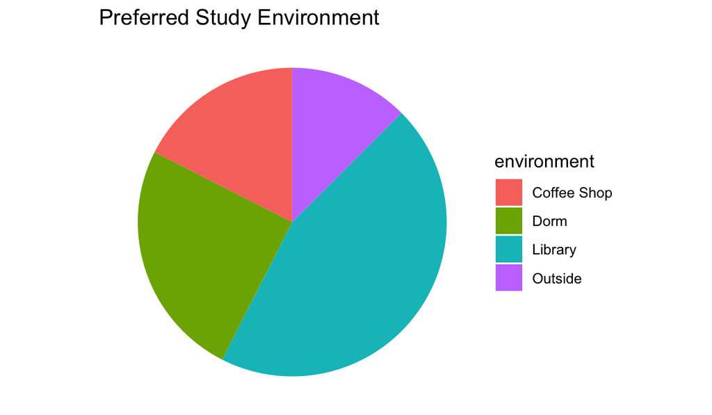

## Scatterplots

**When to Use:** - Both variables are quantitative/continuous. - Examining associations (direction, strength, and form).

**When NOT to Use:** - When variables are categorical.

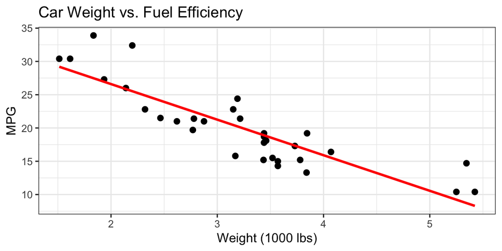

## Column Charts

**When to Use:** - Comparing counts or means across discrete categories.

**When NOT to Use:** - Showing the shape of a continuous distribution. - Showing relationships between two continuous variables.

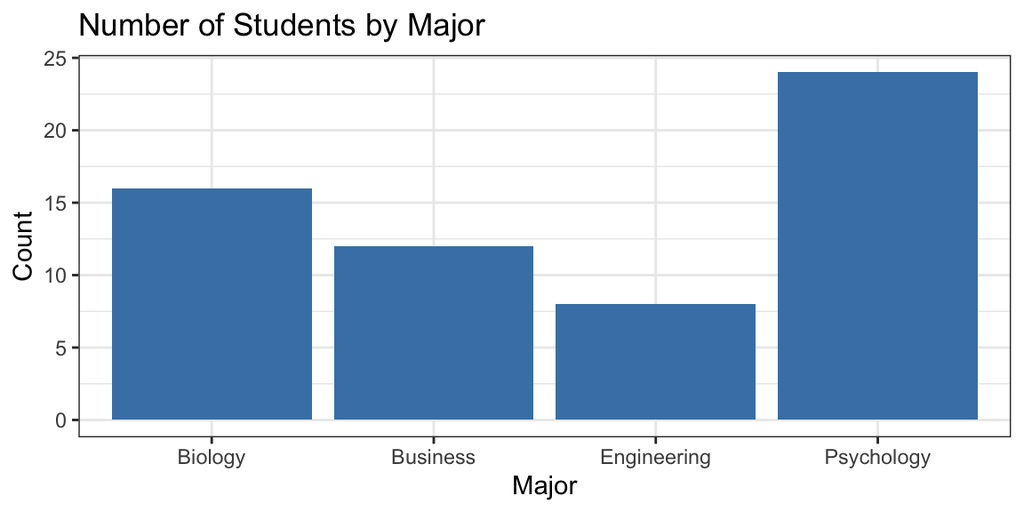

## Boxplots

**When to Use:** - Comparing the distribution of a continuous variable across groups. - Showing center (median), spread (IQR), and outliers compactly.

**When NOT to Use:** - When the exact shape/detail of the distribution is necessary. - Very small sample sizes.

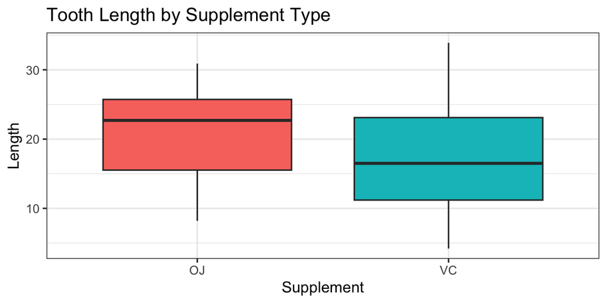

## APA-Style Figures

When presenting results, figures must be clear, professional, and disciplinary-consistent.

**Hallmarks of an APA-Style Figure:** - Simple, readable fonts and clear axis labels. - No unnecessary background effects or 3D decoration. - Minimal visual clutter (prefer `theme_classic()`). - Informative captions explaining the variables and error bars.

> **Rule of Thumb:** Prefer clarity over visual flair. If it prints well in grayscale, it’s usually a good start.

## Error Bars: Showing Uncertainty

When graphing a group mean, the mean is only a summary. **Error bars** represent uncertainty or variability.

**Types of Error Bars:** 1. **Standard Deviation (SD):** Shows how spread out individual observations are. 2. **Standard Error (SE):** Shows how precisely the sample mean estimates the population mean. 3. **Confidence Interval (CI):** Gives a range of plausible values for the population parameter.

*Warning: Always explicitly state what your error bars represent in your figure caption!*

## Error Bars - Column Chart

Point plots are often preferred over bar charts for showing means, as they emphasize the estimate rather than the raw total.

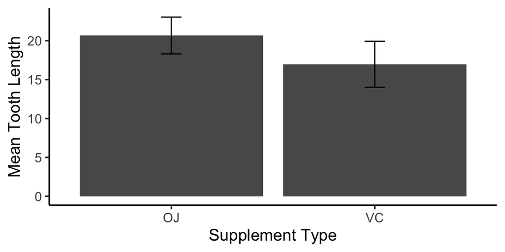

## Error Bars - Point Plot

Point plots are often preferred over bar charts for showing means, as they emphasize the estimate rather than the raw total.

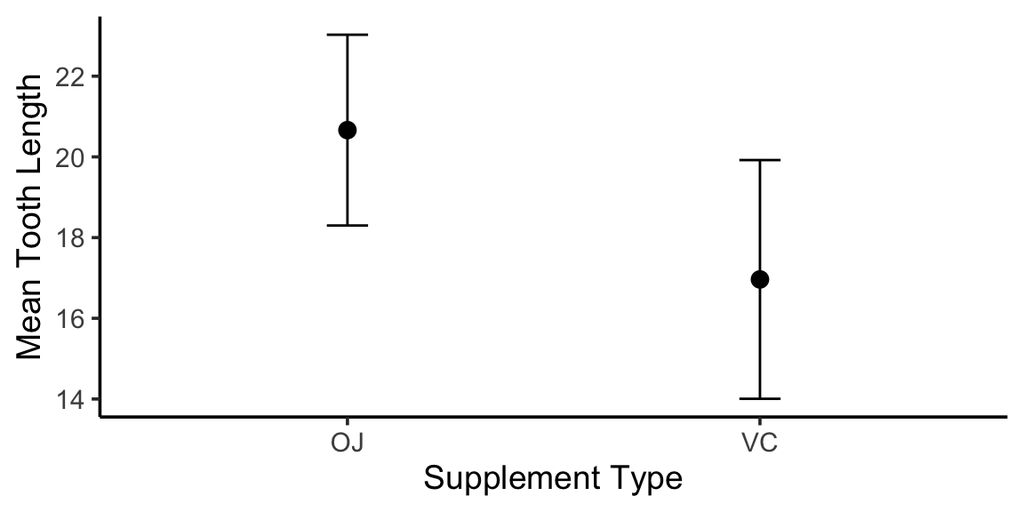

## Line Charts

**When to Use:** - X-axis is logically ordered (e.g., Time). - Highlighting trends, trajectories, or repeated measurements.

**When NOT to Use:** - Unordered categories (e.g., comparing Biology to Psychology).

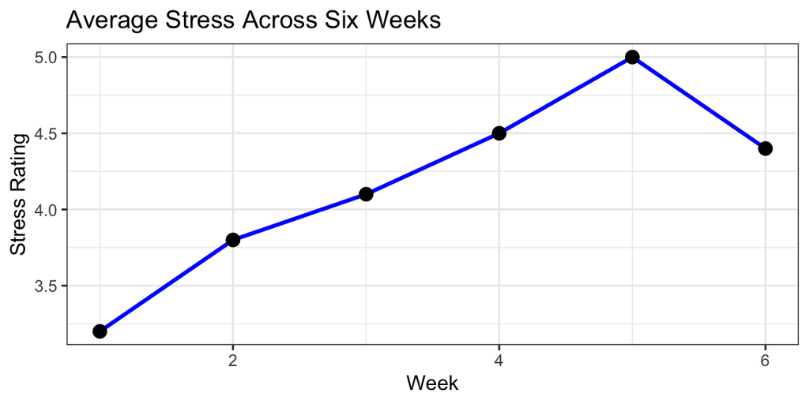

## Line Charts: Multiple Groups & Error Bars

**When to Use:** - You have an ordered sequence (like time) on the x-axis. - You are comparing **two or more groups** across that sequence. - You need to show both the trend (the line) and the uncertainty (the error bars).

*Crucial R Tip:* To draw separate lines for each group, you must tell `ggplot2` to group the data using `group = your_category_variable` inside the `aes()` function!

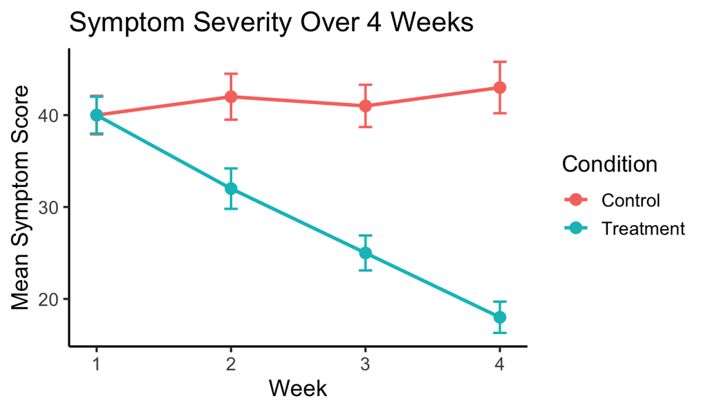

## Common Mistakes to Avoid

1. **Pie chart overload:** Using a pie chart for too many categories hides small differences.
2. **Categorical continuous data:** Using a column chart for a continuous distribution (use a histogram instead).
3. **False continuity:** Using a line chart for unordered categories.
4. **Hiding the spread:** Using a chart of means when variability/skew heavily impacts the interpretation (use a boxplot instead).
5. **Chart junk:** Adding 3D effects, heavy gridlines, or excessive colors that distract from the data.

## Final Takeaway

> “Plots and graphs are not just decorative. They are tools for reasoning about data.”

Ask yourself **“What relationship, pattern, or comparison am I trying to show?”** That question will usually point you to the correct graph.

# Making Graphs in Jamovi

Many plots/graphs can be generated directly from the Jamovi menus and/or within the options of the analysis you are using.

When Jamovi lacks the option to make a plot/graph, you can use the RjEditor plugin.

# Scatterplots in Jamovi

1. Identify two continuous variables
2. Select `Explore > Scatterplot`
3. Add your variables to the X and Y axis fields
4. Select options as desired

[figure not shown]

# Boxplots/Bar plots/Histograms in Jamovi

1. One continuous variable summarized across levels of a categorical (grouping) variable
2. Select `Explore > Descriptives`
3. Add your continuous variable to the “Variables” field
4. Add your categorical variable to the “Split-by” field
5. Select options as desired

**NOTE:** Error bars represent the 95% confidence interval around the mean.

[figure not shown]

# Grouped Boxplots/Bar plots in Jamovi

1. You can create grouped bar charts and boxplots by adding more categorical variables to the “Split-by” field

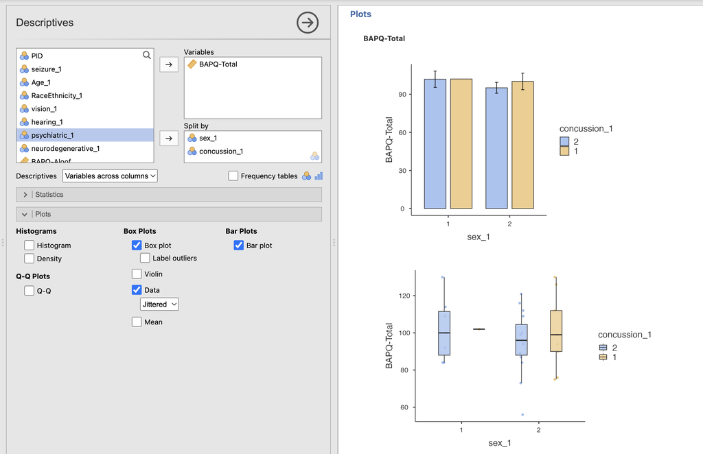

# Pie Charts

- No point-and-click option
- However……You can use the `RjEditor` add-on module and a few lines of R code.

[figure not shown]

# Exporting Figures

1. When you are ready to put figures from Jamovi into your document, you should export a copy to a directory on your computer.
2. right-click > image > export

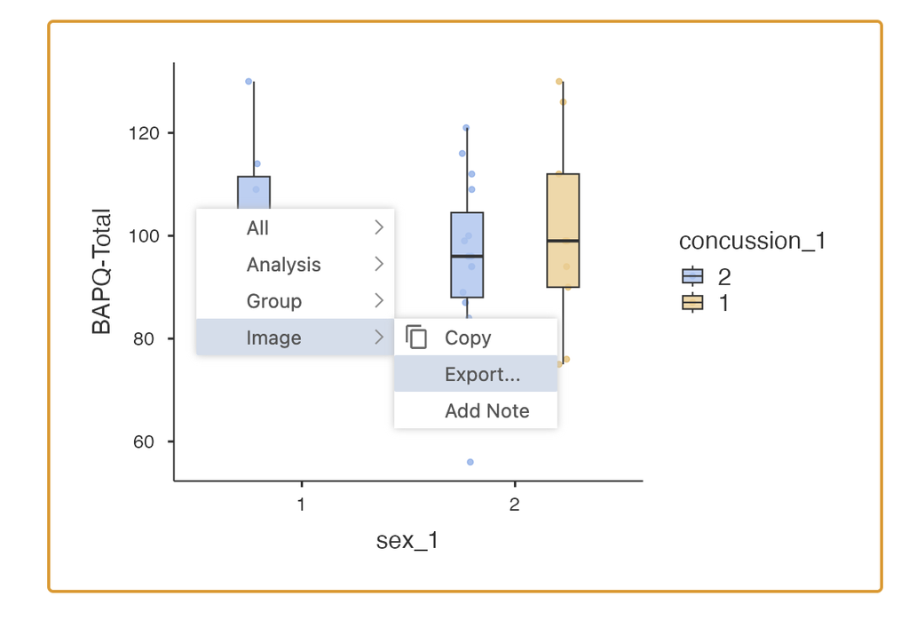

**Choose .png as file type when saving**

# Cleaning Up Jamovi Figures

1. Notice that the figures in Jamovi may not have appealing axis and/or tick labels.

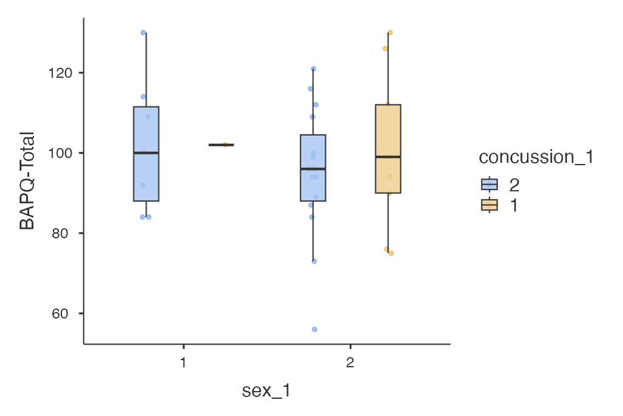

# Editing Figures

- Jamovi Graphs/Plots can be easily manipulated in many different programs
- I use Google Slides!

[figure not shown]

# Clean Figure

1. Use text boxes to cover up unsightly Jamovi labels.

[figure not shown]